# Первое занятие по R. Введение и регрессия

# 1 Загрузка и установка пакетов

Вся прелесть R заключается в том, что это открытое ПО - каждый может написать свою функцию (или набор функций) и предоставить ее для использования всем желающим. Большинство вещей, которые мы с вами будем делать, находится именно в таких “наборах” - пакетах или packages. Каждый пакет нужно (1) загрузить и (2) подключить (установить). При этом загружать пакет нужно один раз, а подключать - при каждом запуске, и только те, которые необходимы.

Сегодня нам понадобятся пакеты:

- `rio` - импортирует и экспортирует данные практически во все известные форматы
- `tidyverse` - включает много пакетов, нам нужны `dplyr` для манипуляций с данными и `ggplot2` для построения графиков
- `skimr` - описательная статистика
- `corrplot`- визуализация корреляций
- `lmtest` - линейные модели и их тестирование
- `miceadds` - всякие коррекции, нам нужна кластерная коррекция регрессионных ошибок
- `sjPlot` - красивое представление данных и результатов анализа

Для того, чтобы **впервые** установить необходимые пакеты можно:

1. Зайти в `Tools` - `Install packages` и написать, что вы хотите от R. Мы хотим много пакетов, так что напишем их через запятую: `rio, tidyverse, skimr, corrplot, lmtest, miceadds, sjPlot`
2. Если вы тру программист - написать в консоли или скрипте `install.packages`. В нашем случае: `install.packages(rio, tidyverse, skimr, corrplot, lmtest, miceadds, sjPlot)`

Для того, чтобы **использовать уже загруженные пакеты**, нужно их подключить с помощью команды `library()`. Подключим те пакеты, которые будем использовать сегодня:

```r
library(rio)
library(tidyverse)
library(skimr)
```

```r
library(corrplot)
library(lmtest)
library(miceadds)
library(sjPlot)
```

# 2 Загрузка данных

Важно задать рабочую директорию. Если у вас и скрипт, и данные лежать в одной папке, то нужно сказать об этом R: открыть нужный скрипт и зайти в `Session` - `Set working directory` - `To source file location`.

Мы будем работать с данными TIMSS-2015 8 класс. Я подготовила и сократила базу данных, чтобы было легче с ними работать. Кроме тогo, я их сохранила в самом простом формате - .csv.

Есть два основных способа загрузить данные. Во-первых, через встроенную функцию `read.формат` (но есть сложности с другими форматами)

```r
timss <- read.csv("timss15_short.csv")
```

Во-вторых (и гораздо проще) - воспользоваться функцией `import` из пакета `rio`

```r
timss <- import("timss15_short.csv")
```

# 3 Смотрим на данные

*Что в данных тебе моих?* Для этого используются команды из пакета `dplyr`, который также есть в более широком пакете `tidyverse` `glimpse`- показывает данные и характеристики переменных `head` - первыенесколько строк базы

```r
glimpse(timss)
```

```
## Observations: 4,780
## Variables: 13
## $ idschool    <int> 1, 1, 1, 1, 1, 1, 1, 1, 1, 1, 1, 1, 1, 1, 1, 1, 1,...
## $ idclass     <int> 102, 102, 102, 102, 102, 102, 102, 102, 102, 102, ...
## $ idstud      <int> 10201, 10202, 10203, 10205, 10206, 10207, 10208, 1...
## $ itsex       <chr> "Male", "Male", "Female", "Male", "Male", "Female"...
## $ st_age      <dbl> 15.42, 15.50, 14.25, 14.92, 14.58, 14.58, 14.67, 1...
## $ totwgt      <dbl> 432.2040, 432.2040, 432.2040, 432.2040, 432.2040, ...
## $ like_math   <chr> "Very Much Like Learning Mathematics", "Like Learn...
## $ area        <chr> "Suburban, on fringe of urban area", "Suburban, on...
## $ matwgt      <dbl> 432.2040, 432.2040, 432.2040, 432.2040, 432.2040, ...
## $ teach_exp   <int> 26, 26, 26, 26, 26, 26, 26, 26, 26, 26, 26, 26, 26...
## $ math_achiev <dbl> 536.2615, 517.9897, 496.9348, 455.8034, 374.2159, ...
## $ sci_achiev  <dbl> 551.4632, 445.3326, 438.1896, 449.3848, 384.8113, ...
## $ par_edu     <chr> "No higher", "No higher", "No higher", "No higher"...
```

```r
head(timss)
```

```
##   idschool idclass idstud  itsex st_age  totwgt
## 1        1     102  10201   Male  15.42 432.204
## 2        1     102  10202   Male  15.50 432.204
## 3        1     102  10203 Female  14.25 432.204
## 4        1     102  10205   Male  14.92 432.204
## 5        1     102  10206   Male  14.58 432.204
## 6        1     102  10207 Female  14.58 432.204
##                             like_math                              area
## 1 Very Much Like Learning Mathematics Suburban, on fringe of urban area
## 2           Like Learning Mathematics Suburban, on fringe of urban area
## 3           Like Learning Mathematics Suburban, on fringe of urban area
## 4 Very Much Like Learning Mathematics Suburban, on fringe of urban area
## 5           Like Learning Mathematics Suburban, on fringe of urban area
## 6           Like Learning Mathematics Suburban, on fringe of urban area
##    matwgt teach_exp math_achiev sci_achiev   par_edu
## 1 432.204        26    536.2615   551.4632 No higher
## 2 432.204        26    517.9897   445.3326 No higher
## 3 432.204        26    496.9348   438.1896 No higher
## 4 432.204        26    455.8034   449.3848 No higher
## 5 432.204        26    374.2159   384.8113 No higher
## 6 432.204        26    435.4901   451.3110 No higher
```

Сколько наблюдений и переменных в данных?

Для описательных статистик используем пакет `skimr`

```r
skim(timss)
```

```
## Skim summary statistics
##  n obs: 4780
##  n variables: 13
```

```
##
## Variable type: character
##   variable missing complete    n min max empty n_unique
##       area       0     4780 4780  12  33     0        5
##      itsex       0     4780 4780   4   6     0        2
##  like_math       0     4780 4780   0  35     2        5
##    par_edu       0     4780 4780   6  10     0        4
##
## Variable type: integer
##   variable missing complete    n     mean       sd    p0       p25   p50
##    idclass       0     4780 4780 10373.66  5991.66   102   5301    10401
##   idschool       0     4780 4780   103.72    59.91     1     53      104
##     idstud       0     4780 4780 1e+06    6e+05    10201 530110.75 1e+06
##  teach_exp     107     4673 4780    23.15    11.17     1     15       25
##         p75  p100     hist
##    15702    20401 ▇▆▇▇▆▇▇▇
##      157      204 ▇▆▇▇▆▇▇▇
##  1570213.25 2e+06 ▇▆▇▇▆▇▇▇
##       32       50 ▅▃▆▆▇▇▃▁
##
## Variable type: numeric
##     variable missing complete    n   mean     sd     p0    p25    p50
##  math_achiev       0     4780 4780 538.36  78.52 298.47 483.74 541.47
##       matwgt       0     4780 4780 259.12 147.01  59.23 189.29 234.12
##   sci_achiev       0     4780 4780 544.78  72.53 305.1  496.79 548.62
##       st_age       0     4780 4780  14.76   0.42  13.25  14.5   14.75
##       totwgt       0     4780 4780 263.14 155.8   77.53 190.34 234.36
##     p75    p100     hist
##  595.46  761.34 ▁▂▅▇▇▆▂▁
##  271.05 1118.35 ▃▇▁▁▁▁▁▁
##  594.57  774.97 ▁▁▃▆▇▅▁▁
##   15      17.67 ▁▂▇▆▁▁▁▁
##  271.05 1118.35 ▅▇▁▁▁▁▁▁
```

```r
#Или для одной переменной
skim(timss$math_achiev)
```

```
## Skim summary statistics
##
## Variable type: numeric
##           variable missing complete    n   mean    sd     p0    p25    p50
##  timss$math_achiev       0     4780 4780 538.36 78.52 298.47 483.74 541.47
##     p75   p100     hist
##  595.46 761.34 ▁▂▅▇▇▆▂▁
```

```r
summary(timss$math_achiev)
```

```
##    Min. 1st Qu.  Median    Mean 3rd Qu.    Max.
##   298.5   483.7   541.5   538.4   595.5   761.3
```

Какие характеристики выводит команда `skim`? Почему переменные разбиты на несколько групп?

Если у вас есть категориальные переменные, нужно предупредить об этом R! R они известы под кодовым названием *фактор*.

Просим R переделать наши переменные типа character в типа factor.

Обратите внимание: базаданных$переменная

```r
timss$area <- as.factor(timss$area)
timss$itsex <- as.factor(timss$itsex)
timss$like_math <- as.factor(timss$like_math)
timss$par_edu <- as.factor(timss$par_edu)
```

Проверяем

```r
skim(timss)
```

```
## Skim summary statistics
##  n obs: 4780
##  n variables: 13
##
## Variable type: factor
##   variable missing complete    n n_unique
##       area       0     4780 4780        5
##      itsex       0     4780 4780        2
##  like_math       0     4780 4780        5
##    par_edu       0     4780 4780        4
##                                top_counts ordered
##  Urb: 1558, Med: 1400, Sub: 693, Rem: 641   FALSE
##               Mal: 2485, Fem: 2295, NA: 0   FALSE
##   Lik: 2295, Do : 1575, Ver: 895, Omi: 13   FALSE
##   No : 2171, Hig: 1979, Don: 602, Unk: 28   FALSE
##
## Variable type: integer
##   variable missing complete    n     mean       sd    p0       p25   p50
##    idclass       0     4780 4780 10373.66  5991.66   102   5301    10401
##   idschool       0     4780 4780   103.72    59.91     1     53      104
##     idstud       0     4780 4780 1e+06    6e+05    10201 530110.75 1e+06
##  teach_exp     107     4673 4780    23.15    11.17     1     15       25
##         p75  p100     hist
##    15702    20401 ▇▆▇▇▆▇▇▇
##      157      204 ▇▆▇▇▆▇▇▇
##  1570213.25 2e+06 ▇▆▇▇▆▇▇▇
##       32       50 ▅▃▆▆▇▇▃▁
##
## Variable type: numeric
##     variable missing complete    n   mean     sd     p0    p25    p50
##  math_achiev       0     4780 4780 538.36  78.52 298.47 483.74 541.47
##       matwgt       0     4780 4780 259.12 147.01  59.23 189.29 234.12
##   sci_achiev       0     4780 4780 544.78  72.53 305.1  496.79 548.62
##       st_age       0     4780 4780  14.76   0.42  13.25  14.5   14.75
##       totwgt       0     4780 4780 263.14 155.8   77.53 190.34 234.36
##     p75    p100     hist
##  595.46  761.34 ▁▂▅▇▇▆▂▁
##  271.05 1118.35 ▃▇▁▁▁▁▁▁
##  594.57  774.97 ▁▁▃▆▇▅▁▁
##   15      17.67 ▁▂▇▆▁▁▁▁
##  271.05 1118.35 ▅▇▁▁▁▁▁▁
```

Смотрим на распределение количественной переменной: самый-самый простой график

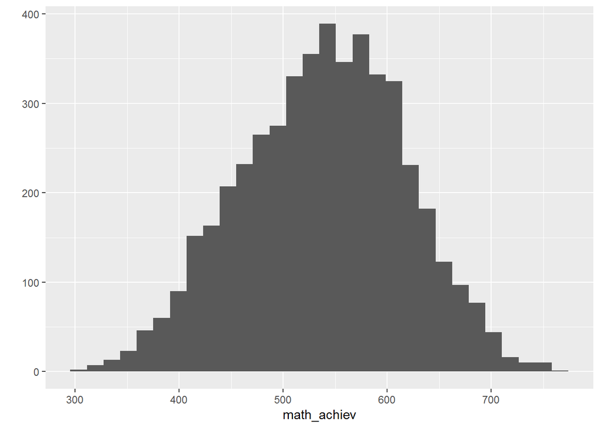

```r
qplot(data = timss, x = math_achiev)
```

Что за график и что туда можно добавить - HELP!

```r
?qplot
```

Добавляем названия переменных и графика, чтобы он стал красивее

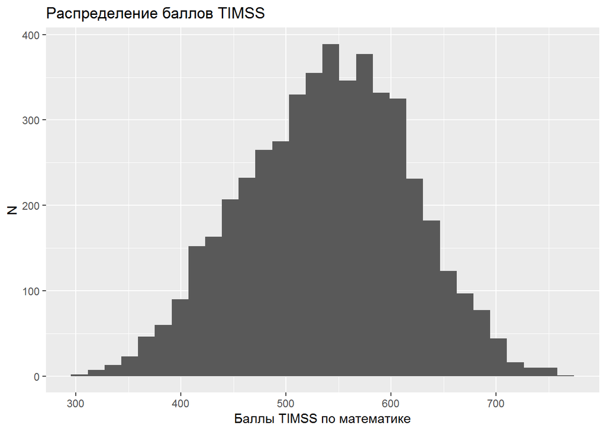

```r
qplot(data = timss, x = math_achiev) +
  labs(x = 'Баллы TIMSS по математике', y = 'N', title = 'Распределение баллов TIMSS')
```

Что внутри у неколичественных переменных?

```r
levels(timss$itsex)
```

```
## [1] "Female" "Male"
```

```r
table(timss$itsex)
```

```
##
## Female   Male
##   2295   2485
```

Сколько значений принимает переменная Пол? На какой шкале измерена? Сколько девочек? Сколько мальчиков?

Посмотрим на переменную “Образование родителей”:

```r
table(timss$par_edu)
```

```
##
## Don't know     Higher  No higher    Unknown
##        602       1979       2171         28
```

У нас есть два значения, которые означают то же самое. Какие? Давайте сделаем из них одно в новую переменную **par_hedu** с помощью команды `fct_collapse`

```r
?fct_collapse
```

```r
timss$par_hedu <- fct_collapse(timss$par_edu, Missing = c("Unknown", "Don't know"))
table(timss$par_hedu)
```

```
##
##   Missing    Higher No higher
##       630      1979      2171
```

```r
timss$par_hedu[timss$par_hedu == "Unknown"] <- NA
table(timss$par_hedu)
```

```
##
##   Missing    Higher No higher
##       630      1979      2171
```

# 4 Как связаны переменные?

Для категориальных переменных мы строим таблицы сопряженности

```r
table(timss$itsex, timss$par_hedu)
```

```
##
##          Missing Higher No higher
##   Female     269    917      1109
##   Male       361   1062      1062
```

Красивые таблицы сопряженности с процентами и с проверкой значимости связи меожно построить с помощью пакета sjPlot

```r
?sjt.xtab
```

```r
sjt.xtab(timss$itsex, timss$area, show.na = TRUE,
         var.labels = c('Sex','Area'),
         show.cell.prc = TRUE,show.row.prc = TRUE)
```

| Sex | Area |  |  |  |  |  | Total |  |
| --- | --- | --- | --- | --- | --- | --- | --- | --- |
|  | Medium size city or large town | Remote rural | Small town or village | Suburban, on fringe of urban area | Urban, densely populated | NA |  |  |
| Female | 702 30.6 % 14.7 % | 309 13.5 % 6.5 % | 251 10.9 % 5.3 % | 310 13.5 % 6.5 % | 723 31.5 % 15.1 % | 0 0 % 0 % |  | 2295 100 % 48.1 % |
| Male | 698 28.1 % 14.6 % | 332 13.4 % 6.9 % | 237 9.5 % 5 % | 383 15.4 % 8 % | 835 33.6 % 17.5 % | 0 0 % 0 % | 2485 100 % 52 % |  |
| NA | 0 0 % 0 % | 0 0 % 0 % | 0 0 % 0 % | 0 0 % 0 % | 0 0 % 0 % | 0 0 % 0 % | 0 100 % 0 % |  |
| Total | 1400 29.3 % 29.3 % | 641 13.4 % 13.4 % | 488 10.2 % 10.2 % | 693 14.5 % 14.5 % | 1558 32.6 % 32.6 % | 0 0 % 0 % | 4780 100 % 100 % |  |

Для количественных - scatterplot…

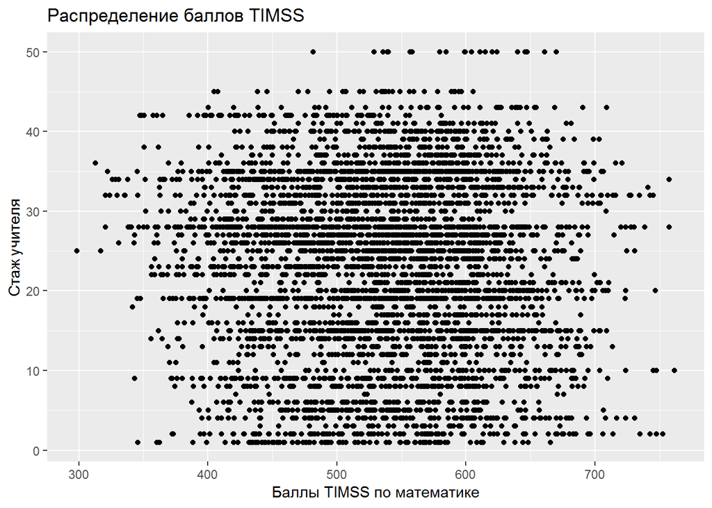

```r
qplot(data = timss, x = math_achiev, y = teach_exp) +
  labs(x = 'Баллы TIMSS по математике', y = 'Стаж учителя', title = 'Распределение баллов TIMSS')
```

…и корреляции. Но для корреляции нужно создать датафрейм, так что отберем все количественные переменные в отдельный датафрейм с помощью комманды `subset`

```r
corrdata <- subset(na.omit(timss), select = c(math_achiev, sci_achiev, teach_exp, st_age))
```

Итак, посчитаем корреляцию между всеми переменными

```r
corm <- cor(corrdata)
corm
```

```
##             math_achiev  sci_achiev   teach_exp      st_age
## math_achiev  1.00000000  0.84121258 -0.02616683 -0.10146317
## sci_achiev   0.84121258  1.00000000 -0.06259555 -0.09106774
## teach_exp   -0.02616683 -0.06259555  1.00000000 -0.05106345
## st_age      -0.10146317 -0.09106774 -0.05106345  1.00000000
```

и визуализируем полученные корреляции

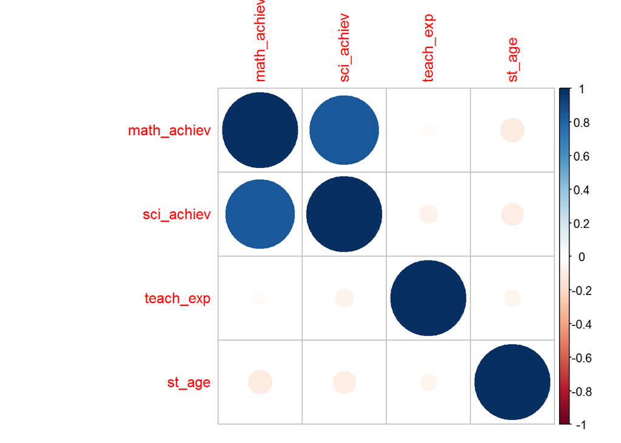

```r
corrplot(corm)
```

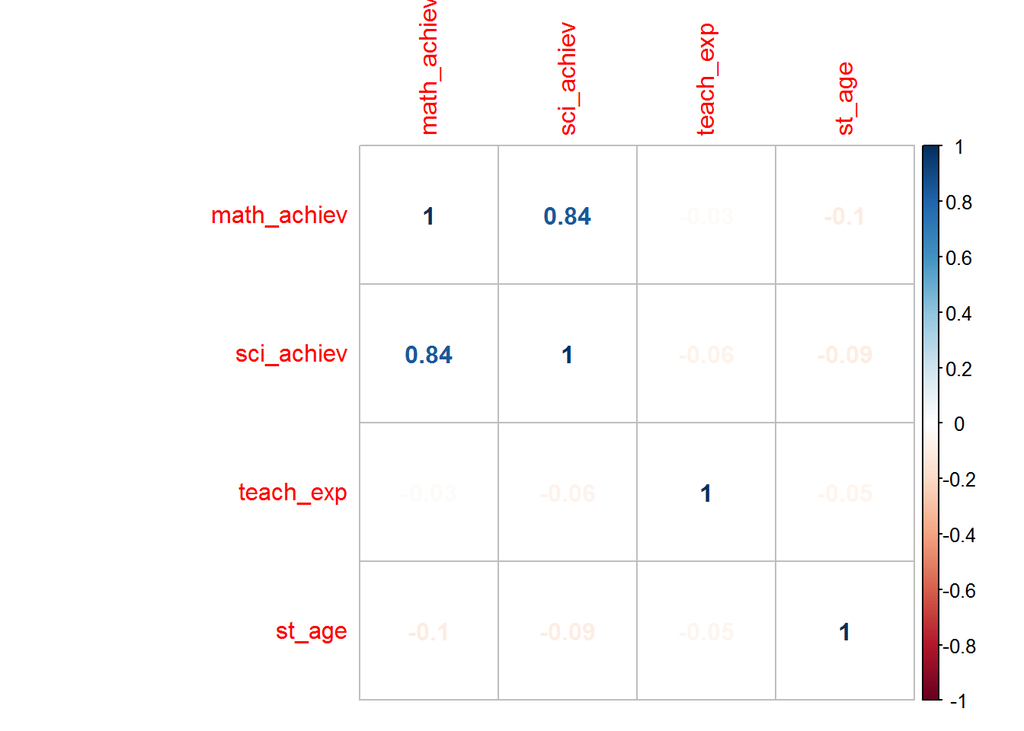

```r
corrplot(corm, method = "number")
```

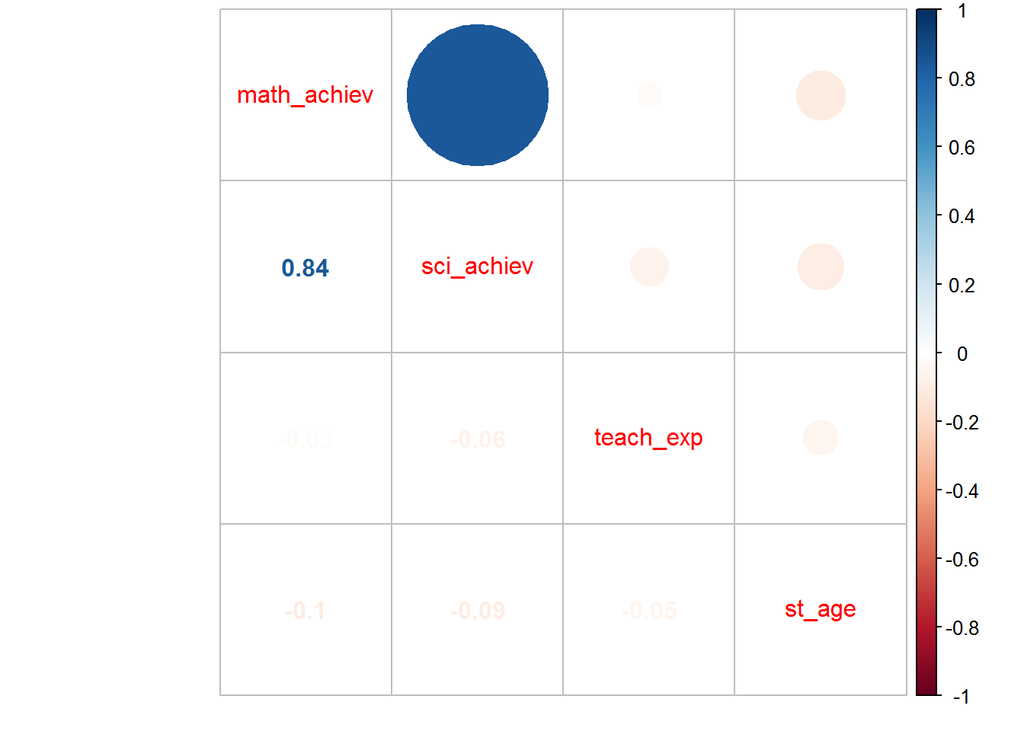

```r
corrplot.mixed(corm)
```

# 5 Приступаем к линейной регрессии!

Для начала построим самую простую регрессию с достижениями по математике в качестве зависимой переменной и стажем учителя в качестве независимой. Для этого используем команду `lm` (linear models)

В R, как и в STATA, вы должны записать формулу регрессии, зависимая переменная - слева

```r
lm(data = timss, math_achiev ~ teach_exp)
```

```
##
## Call:
## lm(formula = math_achiev ~ teach_exp, data = timss)
##
## Coefficients:
## (Intercept)    teach_exp
##    541.7440      -0.1836
```

Что мы видим в аутпуте? Что мы хотим видеть?

Для того, чтобы увидеть, то, что мы хотим, сформируем список с характеристиками модели

```r
model1 <- lm(data = timss, math_achiev ~ teach_exp)
summary(model1)
```

```
##
## Call:
## lm(formula = math_achiev ~ teach_exp, data = timss)
##
## Residuals:
##      Min       1Q   Median       3Q      Max
## -238.688  -54.180    3.254   56.705  221.959
##
## Coefficients:
##             Estimate Std. Error t value Pr(>|t|)
## (Intercept) 541.7440     2.6371 205.430   <2e-16 ***
## teach_exp    -0.1836     0.1026  -1.789   0.0737 .
## ---
## Signif. codes:  0 '***' 0.001 '**' 0.01 '*' 0.05 '.' 0.1 ' ' 1
##
## Residual standard error: 78.33 on 4671 degrees of freedom
##   (107 observations deleted due to missingness)
## Multiple R-squared:  0.0006847,  Adjusted R-squared:  0.0004708
## F-statistic:   3.2 on 1 and 4671 DF,  p-value: 0.07368
```

Визуализируем полученную прямую

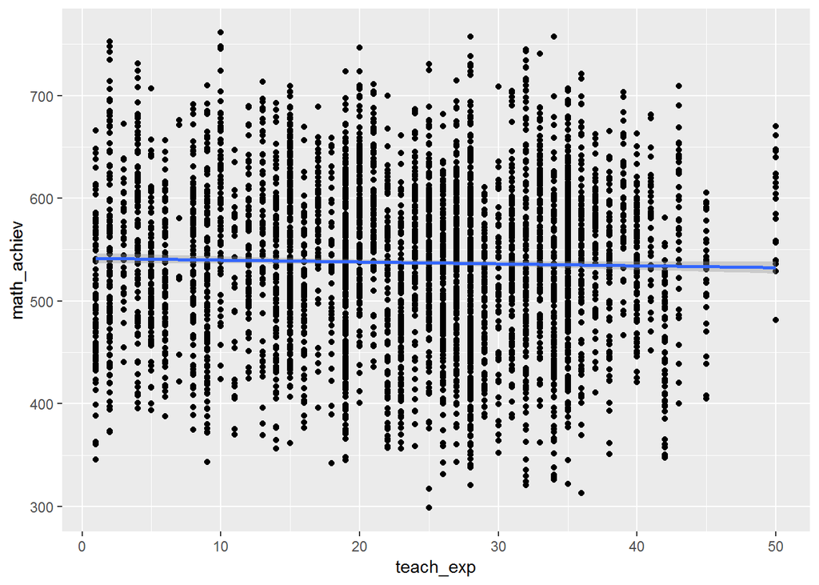

```r
ggplot(data = timss, aes(x = teach_exp, y = math_achiev)) +
  geom_point() +
  geom_smooth(method = 'lm')
```

А что если она не прямая, а *кривая*?

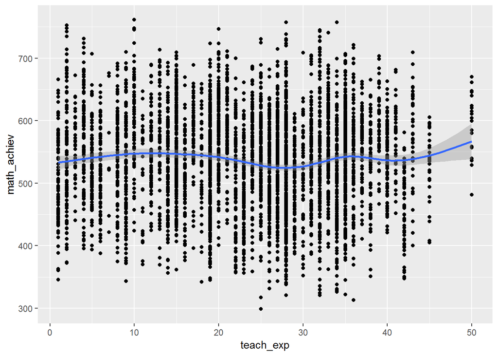

```r
ggplot(data = timss, aes(x = teach_exp, y = math_achiev)) +
  geom_point() +
  geom_smooth()
```

Ну и сделаем красивый график!

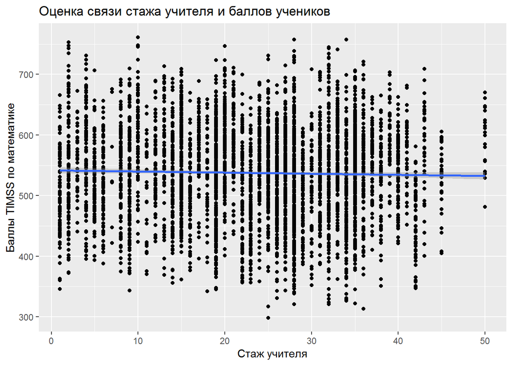

```r
ggplot(data = timss, aes(x = teach_exp, y = math_achiev)) +
  geom_point() +
  geom_smooth(method = 'lm') +
  labs(x = 'Стаж учителя', y = 'Баллы TIMSS по математике', title = 'Оценка связи стажа учителя и баллов учеников')
```

Добавим в модель еще одну независимую переменную - пол ученика. Все независимые перменные добавляются в формулу через `+`

```r
model2 <- lm(data = timss, math_achiev ~ teach_exp + itsex)
summary(model2)
```

```
##
## Call:
## lm(formula = math_achiev ~ teach_exp + itsex, data = timss)
##
## Residuals:
##      Min       1Q   Median       3Q      Max
## -235.033  -55.436    3.137   56.584  224.598
##
## Coefficients:
##             Estimate Std. Error t value Pr(>|t|)
## (Intercept) 538.1222     2.8876 186.357  < 2e-16 ***
## teach_exp    -0.1849     0.1025  -1.803  0.07138 .
## itsexMale     7.0237     2.2916   3.065  0.00219 **
## ---
## Signif. codes:  0 '***' 0.001 '**' 0.01 '*' 0.05 '.' 0.1 ' ' 1
##
## Residual standard error: 78.26 on 4670 degrees of freedom
##   (107 observations deleted due to missingness)
## Multiple R-squared:  0.002691,   Adjusted R-squared:  0.002264
## F-statistic:   6.3 on 2 and 4670 DF,  p-value: 0.001851
```

Изменились ли коэффициенты? R-квадрат? Как связан стаж с баллами по математике? Как связан пол?

Чтобы распространить выводы на всю генеральную совокупность, необходимо использовать взвешенные данные. В TIMSS при использовании данных учителей нужно использовать веса для учителей по анализируемому предмету - в нашем случае matwgt

```r
model2w <- lm(data = timss, math_achiev ~ teach_exp + itsex, weights = matwgt)
summary(model2w)
```

```
##
## Call:
## lm(formula = math_achiev ~ teach_exp + itsex, data = timss, weights = matwgt)
##
## Weighted Residuals:
##     Min      1Q  Median      3Q     Max
## -5066.1  -814.4    53.9   834.5  5150.6
##
## Coefficients:
##             Estimate Std. Error t value Pr(>|t|)
## (Intercept) 536.6117     2.8562 187.879  < 2e-16 ***
## teach_exp    -0.2019     0.1021  -1.979   0.0479 *
## itsexMale     9.9838     2.3012   4.339 1.46e-05 ***
## ---
## Signif. codes:  0 '***' 0.001 '**' 0.01 '*' 0.05 '.' 0.1 ' ' 1
##
## Residual standard error: 1265 on 4670 degrees of freedom
##   (107 observations deleted due to missingness)
## Multiple R-squared:  0.004826,   Adjusted R-squared:  0.0044
## F-statistic: 11.32 on 2 and 4670 DF,  p-value: 1.242e-05
```

Изменились ли коэффициенты? R-квадрат? Как связан стаж с баллами по математике? Как связан пол?

Результаты регрессионного анализа можно красиво представить с помощью функции tab_model из пакета sjPlot. Можно вставить туда только сформулированный список с характеристиками модели, а остальные параметры добавить по желанию

```r
tab_model(model2w,show.se = TRUE,
          show.stat = TRUE)
```

|  | math achiev |  |  |  |  |
| --- | --- | --- | --- | --- | --- |
| Predictors | Estimates | std. Error | CI | Statistic | p |
| (Intercept) | 536.61 | 2.86 | 531.01 – 542.21 | 187.88 | **<0.001** |
| teach exp | -0.20 | 0.10 | -0.40 – -0.00 | -1.98 | **0.048** |
| Male | 9.98 | 2.30 | 5.47 – 14.49 | 4.34 | **<0.001** |
| Observations | 4673 |  |  |  |  |
| R<sup>2</sup> / adjusted R<sup>2</sup> | 0.005 / 0.004 |  |  |  |  |

Как вы помните, наблюдения у нас не независмы - ученики собраны в классы. Поэтому мы применяем кластерную коррекцию остатков из пакета `miceadds`.

```r
model2cl <- lm.cluster(data = timss, formula = math_achiev ~ teach_exp + itsex, cluster = "idclass")
summary(model2cl)
```

```
## R^2= 0.00269
##
##                Estimate Std. Error   t value    Pr(>|t|)
## (Intercept) 538.1222035  8.3350732 64.561185 0.000000000
## teach_exp    -0.1848961  0.3220334 -0.574152 0.565864961
## itsexMale     7.0237206  2.7061617  2.595455 0.009446582
```

Изменились ли коэффициенты? R-квадрат? Как связан стаж с баллами по математике? Как связан пол?